# class1-d

Sujatha Jagannathan

February 6, 2019

## 1. Preparing R

Load packages

```r
library("tidyverse")
library("skimr")
library("here")
```

This should install readr, tidyr, dplyr, purr, stringr, ggplot2, tibble, and forcats.

Set working directory

```r
here()
```

```
## [1] "/Users/sjaganna/Desktop/CU-onedrive/OneDrive - The University of Colorado Denver/08-teaching/molb7910"
```

```r
setwd(here())
```

## 2. Importing data

In base R, we use `read.table`, `read.csv`, `read.delim`, etc. to import data. The problem with these functions is that they often coerce characters and other data types into factors. The tidyverse package `readr` guesses the data type of each column and converts types when appropriate (but does NOT convert strings to factors automatically). We will be using `readr` exclusively to import data in this class. The typical commands used to input data using `readr` are below:

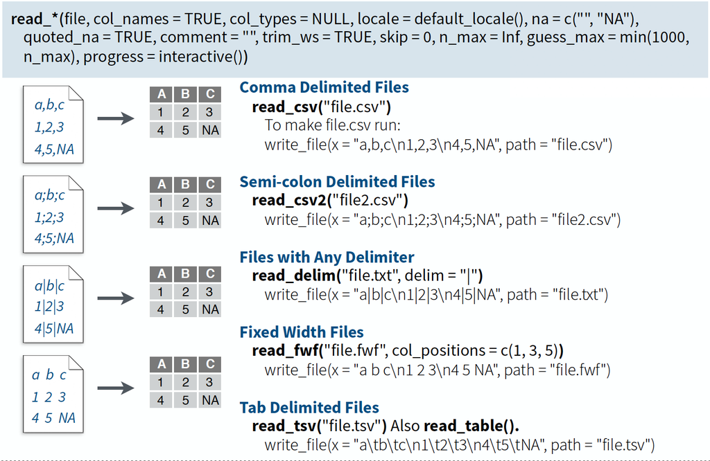

Using some of the following arguments makes it easier to control how we want to input the data.

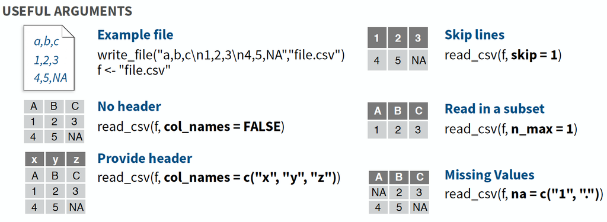

**Note**: All of these functions can also be used in an interactive manner via `Environment` > `Import Dataset` > `From Text (readr)`

#### A. RNA read counts

```r
count_summary_rna <- read_delim(here("1-class1",
                                      "data",
                                     "input",
                                     "count_summary_rna.tsv"),
                                delim = "\t",
                                escape_double = FALSE,
                                trim_ws = TRUE,
                                skip = 1)
```

#### B. Experimental metadata

```r
experiment_metadata <- read_delim(here("1-class1",
                                       "data",
                                       "input",
                                       "experiment-metadata.txt"),
                                  "\t",
                                  escape_double = FALSE,
                                  trim_ws = TRUE)
```

#### C. ENSEMBL to Gene Symbol mapping file

```r
id_mapping <- read_csv(here("1-class1",
                                       "data",
                                       "input",
                                       "id-mapping.csv"))
tx2geneid <- id_mapping
```

## 3. Getting familiar with the data

Some of the useful Data Frame Functions are as follows:  
- `head()` - shows first 6 rows  
- `tail()` - shows last 6 rows  
- `dim()` - returns the dimensions of data frame (i.e. number of rows and number of columns)  
- `nrow()` - number of rows  
- `ncol()` - number of columns  
- `names()` or `colnames()` - both show the names attribute for a data frame  
- `sapply(dataframe, class)` - shows the class of each column in the data frame  
- `str()` - structure of data frame - name, type and preview of data in each column - `glimpse()`

```r
count_summary_rna #this works well with tbl_df data type. Others could take a LONG time

# display first six rows of a dataframe
head(count_summary_rna)

# display last six rows of a dataframe
tail(count_summary_rna)

#Compactly display the internal structure of an R object
str(count_summary_rna)

#Get A Glimpse Of Your Data
glimpse(count_summary_rna)
glimpse(experiment_metadata)
```

#### Summary

A generic function used to produce result summaries of the results of various model fitting functions.

```r
summary(count_summary_rna)
summary(count_summary_rna$`0h_1_RNA_S13_umi.bam`)
```

An alternative to `summary` is `skim`.

```r
library(skimr)
skim(count_summary_rna)
```

#### Table

Uses the cross-classifying factors to build a contingency table of the counts at each combination of factor levels.

```r
table(experiment_metadata$hour)
```

```
##
##  0  4  8 14
##  3  3  3  3
```

#### Plotting

The two simplest plots to use to get a sense of your data are `plot(x)` and `hist(x)`

```r
plot(count_summary_rna$`0h_1_RNA_S13_umi.bam`)

plot(count_summary_rna$`0h_1_RNA_S13_umi.bam`, count_summary_rna$`0h_2_RNA_S14_umi.bam`)

plot(count_summary_rna$`0h_1_RNA_S13_umi.bam`, count_summary_rna$`14h_1_RNA_S22_umi.bam`)

plot(log2(count_summary_rna$`0h_1_RNA_S13_umi.bam`), log2(count_summary_rna$`14h_1_RNA_S22_umi.bam`))

plot(log2(count_summary_rna$`0h_1_RNA_S13_umi.bam`), log2(count_summary_rna$`0h_2_RNA_S14_umi.bam`))

hist(count_summary_rna$`0h_1_RNA_S13_umi.bam`)

hist(log2(count_summary_rna$`0h_1_RNA_S13_umi.bam`))
```

## 4. Tidying and transforming data

What is tidy data?

> “Tidy datasets are all alike but every messy dataset is messy in its own way” Hadley Wickham

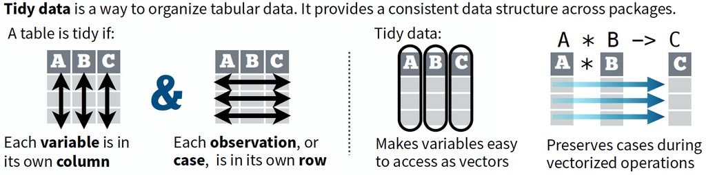

#### Reshaping data

The four verbs to keep in mind for reshaping data with `tidyr` are:  
- `spread`  
- `gather`  
- `separate`  
- `unite`

#### Transforming data

The verbs to keep in mind for transforming data with `dplyr` are:  
- `select`  
- `rename`  
- `arrange`  
- `filter`  
- `mutate`  
- `group_by`  
- `summarise`  
- The pipe: `%>%` - various `join` functions

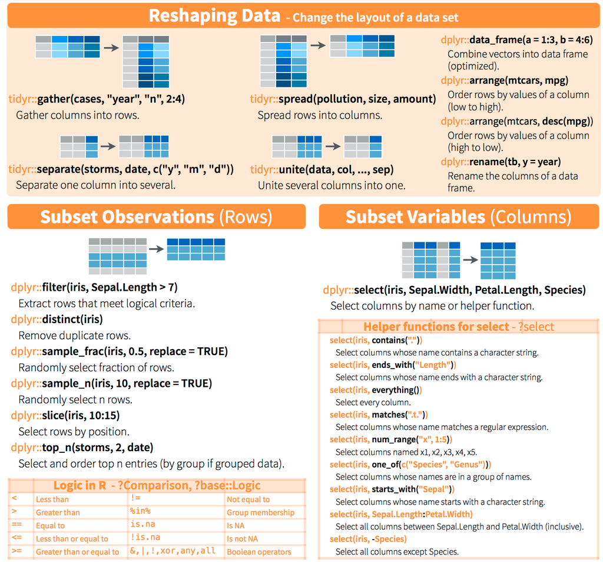

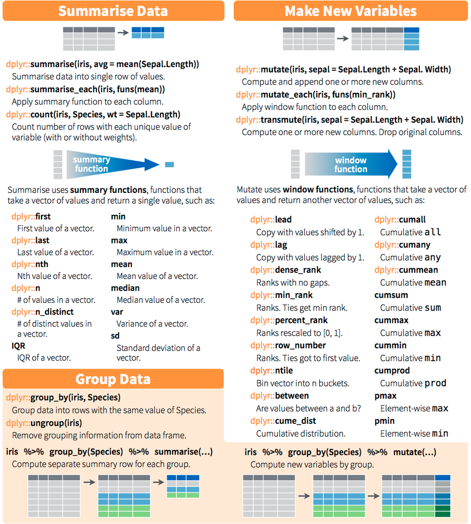

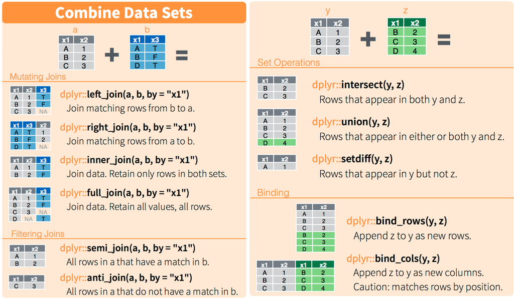

##### Select columns

```r
data <- count_summary_rna %>%
                  select(-Chr, -Start, -End, -Strand)
```

##### Renaming columns

```r
names(data)
```

```
##  [1] "Geneid"                "Length"
##  [3] "0h_1_RNA_S13_umi.bam"  "0h_2_RNA_S14_umi.bam"
##  [5] "0h_3_RNA_S15_umi.bam"  "14h_1_RNA_S22_umi.bam"
##  [7] "14h_2_RNA_S23_umi.bam" "14h_3_RNA_S24_umi.bam"
##  [9] "4h_1_RNA_S16_umi.bam"  "4h_2_RNA_S17_umi.bam"
## [11] "4h_3_RNA_S18_umi.bam"  "8h_1_RNA_S19_umi.bam"
## [13] "8h_2_RNA_S20_umi.bam"  "8h_3_RNA_S21_umi.bam"
```

```r
data <- data %>% rename(hour00_rep1 = `0h_1_RNA_S13_umi.bam`,
                        hour00_rep2 = `0h_2_RNA_S14_umi.bam`,
                        hour00_rep3 = `0h_3_RNA_S15_umi.bam`,
                        hour04_rep1 = `4h_1_RNA_S16_umi.bam`,
                        hour04_rep2 = `4h_2_RNA_S17_umi.bam`,
                        hour04_rep3 = `4h_3_RNA_S18_umi.bam`,
                        hour08_rep1 = `8h_1_RNA_S19_umi.bam`,
                        hour08_rep2 = `8h_2_RNA_S20_umi.bam`,
                        hour08_rep3 = `8h_3_RNA_S21_umi.bam`,
                        hour14_rep1 = `14h_1_RNA_S22_umi.bam`,
                        hour14_rep2 = `14h_2_RNA_S23_umi.bam`,
                        hour14_rep3 = `14h_3_RNA_S24_umi.bam`)
```

##### Rearrange columns

```r
## Using dplyr
# data <- data %>% select(Geneid, Length, hour00_rep1, hour00_rep2, hour00_rep3, hour04_rep1, hour04_rep2, hour04_rep3, hour08_rep1, hour08_rep2, hour08_rep3, hour14_rep1, hour14_rep2, hour14_rep3)

## Alternative with baseR
data <- data[, c(1:5, 9:14, 6:8)]
```

##### Arrange rows by counts

```r
data <- data %>% arrange(hour14_rep1)
data <- data %>% arrange(desc(hour14_rep1))
```

##### Filter rows by counts

```r
data_sub <- data %>% filter(hour14_rep1 > 2000)
```

##### Mutate an observation.

Example: Sum of multiple columns

```r
data_sum <- data %>% mutate(sum_hour00 = sum(hour00_rep1, hour00_rep2, hour00_rep3))
```

##### Merging dataframes

- `join` to map ensembl IDs to gene_symbols

In order to merge the dataframe, we need to first get the Ensembl id in our dataframe to match the Ensembl id in the mapping file. Let’s take a look at these.

```r
head(data$Geneid)
```

```
## [1] "ENST00000550420.2_116_632"   "ENST00000544301.6_414_1812"
## [3] "ENST00000550420.2_722_1007"  "ENST00000370651.5_1154_1673"
## [5] "ENST00000357726.4_28_1477"   "ENST00000318203.9_698_1997"
```

```r
head(tx2geneid$ensembl_transcript_id)
```

```
## [1] "ENST00000375799" "ENST00000397572" "ENST00000289166" "ENST00000377424"
## [5] "ENST00000373027" "ENST00000374135"
```

The Ensembl transcript id in our data table has trailing characters that need to be removed. This is an example of “string manipulation”. `stringr` is a very powerful package for string manipulation in R that would take an entire class (at least) to go through. Instead, we are going to use `tidyr`’s `separate` to accomplish this task.

```r
data <- data %>% separate(Geneid, sep = "\\.", into = c("Geneid", "extra"))

head(data$Geneid)
```

```
## [1] "ENST00000550420" "ENST00000544301" "ENST00000550420" "ENST00000370651"
## [5] "ENST00000357726" "ENST00000318203"
```

On a side note, a handy regex cheatsheet is below:

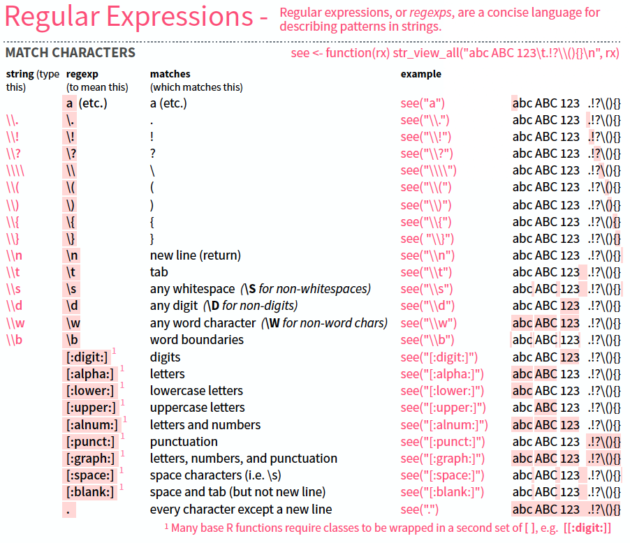

It looks like we have the Geneid in the form we need for merging. Now would be a good time to also get the column names to match to enable easy merging.

```r
# clean up columns of tx2geneid
names(tx2geneid)
```

```
## [1] "X1"                    "ensembl_gene_id"       "ensembl_transcript_id"
## [4] "hgnc_symbol"
```

```r
tx2geneid <- tx2geneid[, c(2:4)]

# renames columns of data
names(data)
```

```
##  [1] "Geneid"      "extra"       "Length"      "hour00_rep1" "hour00_rep2"
##  [6] "hour00_rep3" "hour04_rep1" "hour04_rep2" "hour04_rep3" "hour08_rep1"
## [11] "hour08_rep2" "hour08_rep3" "hour14_rep1" "hour14_rep2" "hour14_rep3"
```

```r
data <- data %>% rename(
  ensembl_transcript_id = Geneid)

data_transcriptlevel <- left_join(data, tx2geneid)
```

$\color{red}{\text{Your turn...}}$ Remove the column `extra` and rearrange the remaining columns in the following order: `gene_symbol`, `ensembl_gene`, `ensembl_transcript`, and everything else.

$\color{red}{\text{Your turn...}}$ Export the data for future use (aka, homework)

##### Summarise the counts via sum to collapse duplicate transcript ids.

```r
# check number of transcripts vs. number of genes
length(data_transcriptlevel$hgnc_symbol)
```

```
## [1] 20037
```

```r
length(unique(data_transcriptlevel$hgnc_symbol))
```

```
## [1] 10509
```

```r
length(unique(data_transcriptlevel$ensembl_gene_id))
```

```
## [1] 10734
```

```r
length(data_transcriptlevel$ensembl_gene_id) # why are these numbers different? Hugo gene symbols can be non-unique. Always use Ensembl ids, if possible.
```

```
## [1] 20037
```

```r
# group_by genes and summarise counts
nrow(data_transcriptlevel)
```

```
## [1] 20037
```

```r
data_genelevel <- data_transcriptlevel %>%
  group_by(ensembl_gene_id, hgnc_symbol) %>%
  summarise(hour00_rep1 = sum(hour00_rep1),
            hour00_rep2 = sum(hour00_rep2),
            hour00_rep3 = sum(hour00_rep3),
            hour04_rep1 = sum(hour04_rep1),
            hour04_rep2 = sum(hour04_rep2),
            hour04_rep3 = sum(hour04_rep3),
            hour08_rep1 = sum(hour08_rep1),
            hour08_rep2 = sum(hour08_rep2),
            hour08_rep3 = sum(hour08_rep3),
            hour14_rep1 = sum(hour14_rep1),
            hour14_rep2 = sum(hour14_rep2),
            hour14_rep3 = sum(hour14_rep3))

nrow(data_genelevel)
```

```
## [1] 10734
```

$\color{red}{\text{Your turn...}}$ Export the data for future use (aka, homework)

## Acknowledgements

Most images, especially the cheat sheets, are from www.rstudio.com